# Missoula’s Housing Capacity Is Already on the Books

The City already plans for roughly 43,000 homes — and can add them by removing the conversion friction between plan and code. Here is how.

Author

Kasey Zapatka

Published

July 29, 2026

**NoteExecutive Summary**

Missoula is considering policy changes to **advance housing affordability and smart growth** as it rewrites its development code under the [2023 Montana Land Use Planning Act](https://www.engagemissoula.com/the-new-montana-land-use-planning-act-sb382). The adopted [Our Missoula 2045 Land Use Plan](https://www.ci.missoula.mt.us/3156/Land-Use-Plan) sets the target: roughly **22,000–27,500 new homes by 2045**.

**The finding:** **The City does not need to find new land or amend its plan to hit that target — it can add roughly 43,000 homes by removing the conversion friction between what the adopted plan already allows and what gets built.** Vacant and economically underbuilt parcels provide ground for ~43,000 homes at conservative midpoint densities — the 2045 target, 1.6 to 2 times over — netting out floodway and steep-slope acres. Half of that capacity is small-scale infill on parcels of five acres or less; the strongest clusters (99% confidence) hold a quarter of it on ~2% of the urban fabric; 58% of it is within a quarter-mile of a bus stop. The binding constraint is not land; it is conversion friction: the review process, infrastructure timing, and zoning that has not caught up with the plan.

**The recommendation:** Align zoned entitlements with the Growth Policy where the capacity clusters (the North Reserve corridor, Linda Vista/Miller Creek, and the South Hills), make small infill by-right, and pair that upzoning with preservation for the ~2,600 lowest-cost homes that sit in the same growth path.

## Approach

We work from the City of Missoula taxlot layer — **32,974 parcels** with existing use, dwelling units, assessed values, current zoning, Growth Policy future land use, and floodplain/steep-slope shares[^1]. For every parcel whose future land-use designation calls for housing, we compute **plan-enabled capacity**: the parcel’s developable acres (net of floodway and steep slope) times an assumed allowable density for its designation, minus the dwelling units already standing[^2].

We then keep only parcels where that capacity is **realistically addressable**: vacant, or economically soft (assessed improvements worth less than the land under them), excluding public and institutional land, parks and open space, master condo records — and mobile-home parks, which score as “soft” but are naturally occurring affordable housing (they get their own finding below, as a risk rather than an opportunity). Finally, a **Getis-Ord Gi*** analysis on a 1,000-ft hex grid finds where that capacity clusters. Full detail: Methods & Sources.

## Finding 1 — The capacity concentrates in a few corridors

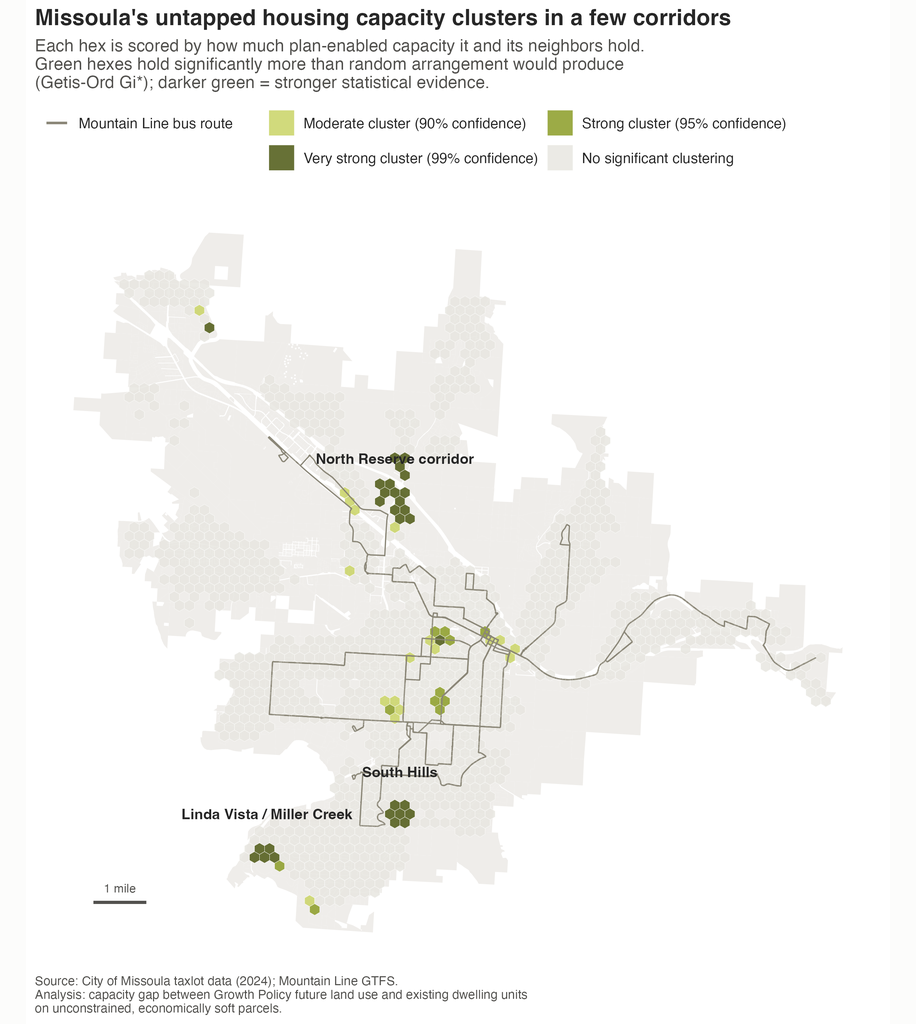

Figure 1: Green hexes hold significantly more plan-enabled capacity — counting each hex together with its neighbors — than a random arrangement of the same parcels would produce (Getis-Ord Gi*); darker green means stronger statistical evidence, not more capacity. The three biggest clusters — labeled and verified by reverse-geocoding — are the North Reserve corridor, the Linda Vista/Miller Creek area, and the South Hills. The 29 hexes at 99% confidence alone hold ~11,400 units — a quarter of the citywide total on ~2% of the urban fabric.

Untapped capacity is not evenly distributed across the city. Aggregated to a 1,000-ft hex grid and tested for spatial clustering, **29 of 1,188 hexes (~2.4%) are capacity clusters at 99% confidence — five times as many as chance would produce — and they hold ~11,400 of the ~43,000 plan-enabled units**. Widening to the 95%+ envelope adds 11 hexes for ~14,600 units; the concentration finding is robust to a false-discovery-rate correction (see Methods). These are the places where code reform, infrastructure investment, and permitting capacity would do the most work per acre: the North Reserve corridor, the Linda Vista/Miller Creek area, and the South Hills, with smaller significant clusters through midtown. The capacity is also transit-aligned in a measurable sense: **58% of all plan-enabled units sit within a quarter-mile walk of one of Mountain Line’s 334 bus stops** (agency GTFS) — growth where zero-fare transit already runs.

## Finding 2 — The plan already makes room for ~43,000 homes

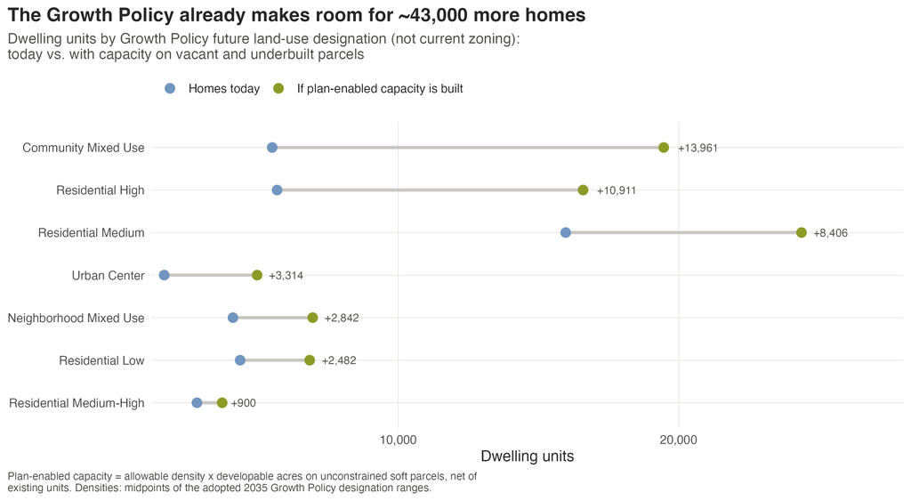

Figure 2: Dwelling units by Growth Policy future land-use designation: homes on the ground today (blue) versus today plus plan-enabled capacity on vacant and underbuilt parcels (green). Community Mixed Use and the medium/high residential designations carry most of the headroom.

Summing across designations, **3,419 opportunity parcels (~4,200 acres) carry ~43,000 plan-enabled units** — nearly enough to double the existing ~44,300-unit stock[^3]. Roughly half of that capacity sits on vacant land and half on economically underbuilt parcels whose improvements are worth less than the land beneath them. This is not a rezoning wish list: every unit is consistent with the future land-use map the City has already adopted, on acreage that nets out floodway and steep-slope land.

## Finding 3 — Half the opportunity is small-scale infill

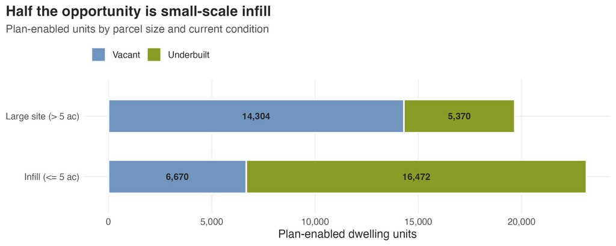

Figure 3: Plan-enabled units by parcel size and current condition. Small parcels (≤ 5 acres) — the scale of an individual owner, a small builder, a neighborhood lot — carry half the citywide total.

Large vacant tracts draw most of the attention, but the volume sits elsewhere: **parcels of five acres or less carry ~23,100 units — 54% of the total**, most of it on *underbuilt* rather than vacant land. The distinction matters for policy design: large-site capacity is unlocked by master planning and infrastructure; small-site capacity is unlocked by **by-right approvals, missing-middle allowances, and simpler review** — exactly the levers a development-code rewrite controls.

## The affordability lens — ~2,600 of the city’s lowest-cost homes sit in the growth path

Missoula is a **majority-renter city**: 52% of households rent, and **half of those renters (49.9%) are cost-burdened**, paying more than 30% of income for housing (ACS 2019–2023). More housing where demand already is would ease that pressure for a large share of the city.

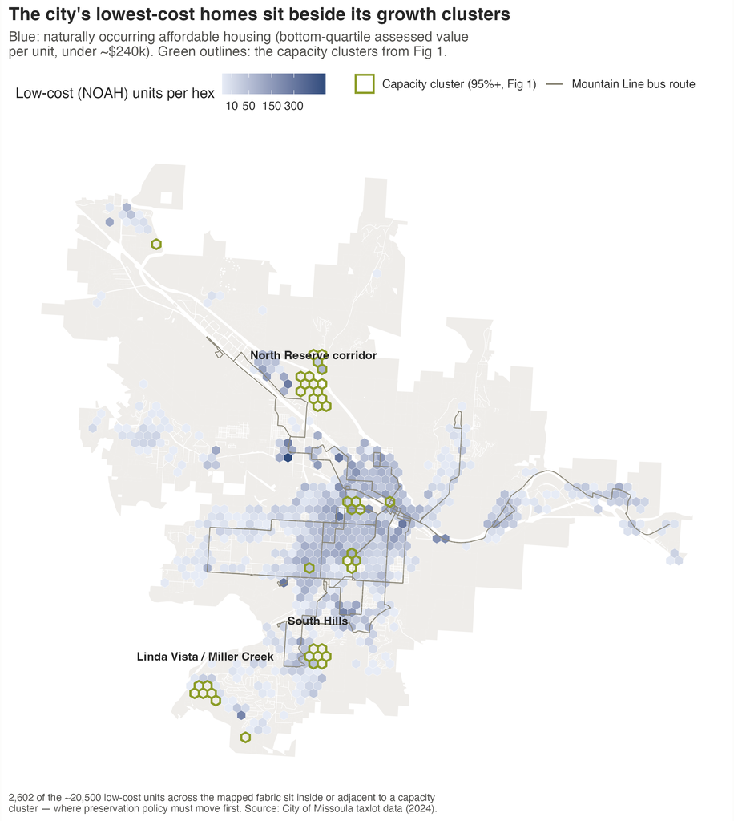

Figure 4: Blue hexes shade where the low-cost stock concentrates; dark-green outlines are the 95%+ capacity clusters from the hero map. The overlap is where displacement pressure would concentrate: **~2,600 low-cost units sit inside or directly adjacent to a capacity cluster.**

The most exposed stock is mobile homes — **530 parcels (~2,850 units) on land the Growth Policy designates for higher density**, which is why they are excluded from the opportunity count entirely. The implication is sequencing: pair upzoning from the start with preservation tools — resident-ownership conversions, NOAH acquisition funds, zoning overlays — in exactly the hexes where the two maps overlap.

## What this means for the code reform

1. **Align zoning with the plan where capacity clusters.** The North Reserve, Linda Vista/Miller Creek, and South Hills clusters are where the gap between the future land-use map and current entitlements costs the most homes. Start the rewrite there.
2. **Make small infill easy.** Half the capacity is on small parcels; by-right missing-middle allowances and streamlined review are the levers that convert it into permitted homes.
3. **Protect the residents already providing affordability.** Preservation for the 530 mobile-home parcels should come before — not after — the surrounding land appreciates.

## Caveats

Plan-enabled capacity is **what the adopted plan makes room for, not a development forecast**: it ignores ownership, market feasibility, and infrastructure timing. Densities use the midpoints of the Growth Policy’s designation ranges — the plan’s ceiling would roughly double the headline. Assessed values proxy price levels, not rents, so the NOAH flag marks *relative* affordability; the quarter-mile walkshed is straight-line, which slightly overstates walk access. The Sxwtpqyen master-plan area carries its own designation, which we conservatively treat as non-residential, so the true total is likely *higher*. See Methods & Sources.

**Data sources.**

- City of Missoula taxlot layer (2024) with assessor, zoning, Growth Policy future land use, and constraint attributes (provided for this exercise)
- Field map / data dictionary accompanying the taxlot layer
- [Mountain Line GTFS feed](https://www.mountainline.com/about/data-portal/) (stops and routes, July 2026)
- [American Community Survey](https://www.census.gov/programs-surveys/acs) 2019–2023 5-year estimates, Missoula city (tenure B25003, rent burden B25070)
- Our Missoula 2035 Growth Policy designation density ranges, as applied in City annexation/rezoning staff reports; [Our Missoula 2045 Land Use Plan](https://www.ci.missoula.mt.us/3156/Land-Use-Plan) housing targets

Analysis and figures: Kasey Zapatka, 2026. Full methodology: Methods & Sources. Code: github.com/kaseyzapatka/cascadia.

## Footnotes

[^1]: Areal math is done in NAD83 State Plane Montana (feet), the layer’s native projection. See Methods & Sources for cleaning decisions, including ~900 curve geometries and the flood/slope fields where missing genuinely means zero.
[^2]: Densities are the midpoints of the adopted 2035 Growth Policy designation ranges (e.g., Residential Medium 3–11 du/ac → 7), as those ranges are applied in the City’s own annexation and rezoning staff reports; they are centralized in `code/00_setup.R`. This is *plan-implied* capacity from the City’s future land-use map, deliberately distinct from current zoning: it measures what the City has already agreed growth should look like.
[^3]: Taxlot dwelling-unit sum (44,317), which includes ~2,050 group-quarters beds on 54 parcels; the ACS counts ~36,000 conventional housing units citywide, so the comparison is indicative rather than census-exact.